# Differential Expression Analysis

This report analyses bulk RNA-seq data from *Staphylococcus aureus* grown as biofilm and planktonic cultures over time, from [Tomlinson *et al.*, 2021](https://doi.org/10.1099/mgen.0.000598) (GEO: GSE163153, PRJNA685119). It follows on from the quality control script and analyses **one strain at a time**: **USA100** (N315 reference) or **USA500** (USA300 reference).

The experiment has two experimental factors: **lifestyle** (biofilm vs planktonic) and **time point** (5 h, 10 h, 24 h). This gives us two distinct biological questions, which we treat separately because they are not the same question:

1. **Maturation** - how does a culture change over time, *within* one lifestyle? (biofilm at 24 h vs 5 h; planktonic at 24 h vs 5 h)
2. **Lifestyle** - how do biofilm and planktonic differ, *accounting for* time? (two models: additive and interaction)

**⭐ Why we do not routinely compare biofilm vs planktonic at a single time point.** At 24 h, planktonic cells are in deep stationary phase while biofilm cells remain metabolically active. Comparing the two lifestyles at that single snapshot mixes together two different things: the effect of *lifestyle* and the effect of *growth phase*. To separate them we either compare within a lifestyle across time (maturation), or model lifestyle while adjusting for time. This is a core idea in experimental design: when two factors vary together, analyse them in a way that lets you tell their effects apart.  
Part 3 makes one deliberate exception, for a question that is specifically about mature biofilm, and says so where it does it. Everywhere else, time is in the model.

## Setup the Environment

```r
library(tidyverse)
library(DESeq2)
library(apeglm)
library(ggpubr)
library(pheatmap)
library(EnhancedVolcano)
library(knitr)
library(kableExtra)
library(DT)
library(gggenes)       # to draw genes as arrows along the chromosome (CRAN)
```

### Choose the Strain

As in the QC script, one setting drives the whole analysis. There are two ways to set it:

1. **Interactively** (running chunks by hand in RStudio/VS Code): edit the `strain` line below.
2. **When rendering** (`rmarkdown::render`, or the `render_all_strains.R` driver): the value comes from the `params:strain` field in the YAML header, which overrides the line below.

```r
# Interactive default. When the document is rendered, params$strain (from the YAML
# header, or passed by rmarkdown::render) takes precedence over this line.
strain <- "USA-100"          # "USA-100" or "USA-500"

# If rendered with a params value, use it.
if (exists("params", inherits = FALSE) && is.list(params) && !is.null(params$strain)) strain <- params$strain

stopifnot(strain %in% c("USA-100", "USA-500"))
strain_tag <- tolower(gsub("-", "", strain))

git_root    <- system("git rev-parse --show-toplevel", intern = TRUE)
results_dir <- file.path(git_root, "results", strain_tag)

# Each strain was aligned to its own reference genome, so each has its own GTF.
gtf_file <- switch(strain,
  "USA-100" = "saureus/usa100_NC_002745/GCF_000009645.1_ASM964v1_genomic.gtf.gz",  # N315
  "USA-500" = "saureus/usa500_USA300/GCF_000013465.1_ASM1346v1_genomic.gtf.gz"     # USA300
)
gtf_path <- file.path(git_root, "data", "genome_files", gtf_file)
stopifnot("reference GTF not found - see data/genome_files/" = file.exists(gtf_path))

# --- Analysis choices, set once and reused everywhere -------------------------
lfc_threshold  <- log2(3)  # paper's 3-fold threshold, on the log2 scale (~1.585)
padj_threshold <- 0.05     # FDR cutoff
# -----------------------------------------------------------------------------

cat("Strain          :", strain, "\n")
```

```
## Strain          : USA-500
```

```r
cat("GTF             :", gtf_path, "\n")
```

```
## GTF             : /Users/jasge/Documents/GitHub/dsp_27200/data/genome_files/saureus/usa500_USA300/GCF_000013465.1_ASM1346v1_genomic.gtf.gz
```

```r
cat(sprintf("log2FC threshold: %.3f (= %g-fold)\n", lfc_threshold, 2^lfc_threshold))
```

```
## log2FC threshold: 1.585 (= 3-fold)
```

```r
cat("padj threshold  :", padj_threshold, "\n")
```

```
## padj threshold  : 0.05
```

### Load the DESeqDataSet from QC

The QC script saved a `DESeqDataSet` containing **all** time points. We load it here and subset as needed for each question.

```r
dds_all <- readRDS(
  file.path(results_dir, "rds", paste0("dds_", strain_tag, "_all_timepoints.rds"))
)

cat("Loaded DDS:", nrow(dds_all), "genes ×", ncol(dds_all), "samples\n\n")
```

```
## Loaded DDS: 2275 genes × 32 samples
```

```r
print(table(dds_all$lifestyle, dds_all$timepoint))
```

```
##
##              5h 10h 24h
##   Planktonic  4   4   8
##   Biofilm     4   4   8
```

```r
dir.create(file.path(results_dir, "tables"), recursive = TRUE, showWarnings = FALSE)
dir.create(file.path(results_dir, "plots"),  recursive = TRUE, showWarnings = FALSE)
dir.create(file.path(results_dir, "rds"),    recursive = TRUE, showWarnings = FALSE)
```

**📌 Remember:** This object already had low-count genes filtered in the QC step. Below we set the reference (baseline) level explicitly for each analysis so the direction of every fold change is unambiguous.

### Factor Order and Reference Level

Before extracting any result, make sure the comparison points the way you think it does. The first factor level is always the reference (denominator) in `DESeq2` comparisons. Setting `Planktonic` as the reference ensures fold changes are computed in the intended direction: **biofilm vs planktonic**, not the reverse.

```r
dds_all$lifestyle <- relevel(dds_all$lifestyle, ref = "Planktonic")
levels(dds_all$lifestyle)
```

```
## [1] "Planktonic" "Biofilm"
```

**📌 Remember:** The reference level determines the direction of fold changes. A positive log2FC will mean higher expression in biofilm relative to planktonic.

### A Small Helper for Extracting and Classifying Results

To avoid repeating the same code for every contrast, we define one helper that takes a fitted `DESeqDataSet`, extracts shrunken results for a named coefficient, and classifies each gene as up, down, or not significant using the shared thresholds.

**📘 Note:** We use `apeglm` shrinkage, which requires the effect to be named via `coef` (a name from `resultsNames()`). Shrinkage pulls in the fold changes of noisy, low-count genes so that the large fold changes that remain are trustworthy. Significance itself comes from a separate test against the 3-fold threshold, so shrinkage no longer decides which genes are counted as Up or Down. It still shapes every plot that reads the fold change.

```r
get_results <- function(dds, coef_name) {
  stopifnot(coef_name %in% resultsNames(dds))
  res_raw <- results(dds, name = coef_name)            # keeps the Wald statistic
  # Test against the 3-fold threshold itself, so padj controls the error rate
  # for the claim we report. Filtering on the estimate afterwards would not.
  res_thr <- results(dds,
                     name          = coef_name,
                     lfcThreshold  = lfc_threshold,
                     altHypothesis = "greaterAbs")
  res     <- lfcShrink(dds, coef = coef_name, type = "apeglm")
  as.data.frame(res) %>%
    rownames_to_column("gene_id") %>%
    mutate(
      # lfcShrink() drops `stat`, so take it from results(). Used to rank genes for GSEA,
      # where the ranking must stay on the test against zero.
      stat   = res_raw[gene_id, "stat"],
      pvalue = res_thr[gene_id, "pvalue"],
      padj   = res_thr[gene_id, "padj"],
      # No fold-change filter: the 3-fold requirement is inside the hypothesis.
      direction = case_when(
        !is.na(padj) & padj < padj_threshold & log2FoldChange > 0 ~ "Up",
        !is.na(padj) & padj < padj_threshold & log2FoldChange < 0 ~ "Down",
        TRUE                                                      ~ "Not significant"
      ),
      direction = factor(direction, levels = c("Up", "Down", "Not significant"))
    ) %>%
    arrange(padj)
}

# Compact volcano wrapper so every contrast is plotted the same way.
# Only the top 5 genes by adjusted p-value are labelled, to keep the plot readable.
plot_volcano <- function(res_df, title, sub, n_label = 5) {
  top_genes <- res_df %>%
    filter(!is.na(padj)) %>%
    arrange(padj) %>%
    slice_head(n = n_label) %>%
    pull(gene_id)

  labels <- ifelse(res_df$gene_id %in% top_genes, res_df$gene_id, "")

  EnhancedVolcano(
    res_df,
    lab            = labels,
    x              = "log2FoldChange",
    y              = "padj",
    ylab           = bquote(~-Log[10] ~ "adjusted" ~ italic(P)),
    pCutoff        = padj_threshold,
    FCcutoff       = lfc_threshold,
    title          = title,
    subtitle       = sub,
    legendPosition = "bottom",
    drawConnectors = TRUE,
    max.overlaps   = Inf
  )
}

# Diagnostic: are the largest fold changes coming from well-expressed genes (real)
# or from low-count genes (unreliable)? Prints the 10 most extreme by |log2FC|
# with their baseMean (mean normalised count across samples).
check_extreme_fc <- function(res_df, n = 10) {
  res_df %>%
    arrange(desc(abs(log2FoldChange))) %>%
    transmute(gene_id,
              baseMean       = round(baseMean, 1),
              log2FoldChange = round(log2FoldChange, 2),
              padj           = signif(padj, 3),
              direction) %>%
    head(n)
}
```

## Part 1 Maturation: How a Culture Changes Over Time

Here we compare the **last** time point to the **first** *within a single lifestyle*. This isolates the effect of time (culture ageing / maturation) with lifestyle held constant, so nothing here is confounded by the biofilm-vs-planktonic difference.

**📘 Note - first vs last, and an invitation to explore.** We compare **24 h vs 5 h** (last vs first). This is the largest maturation window and the clearest teaching contrast. The dataset also has a 10 h time point: you are encouraged to repeat these analyses with `first_tp` and `last_tp` set to other pairs (e.g. 5 h vs 10 h, or 10 h vs 24 h) to see how the maturation signal builds up over time. Nothing else in the code needs to change.

```r
first_tp <- "5h"    # baseline (reference)
last_tp  <- "24h"   # compared against baseline
```

### 1a Maturation within Biofilm

**❓ The question we are answering**

- **Question:** Within biofilm cultures, which genes change between 5 h and 24 h of growth?
- **Contrast:** Biofilm 24 h vs Biofilm 5 h. Reference = 5 h.
- **A positive log2FC means:** higher at 24 h (induced as the biofilm matures).
- **A hit tells you:** this gene is part of the biofilm maturation programme.

```r
dds_bf <- dds_all[, dds_all$lifestyle == "Biofilm" &
                    dds_all$timepoint %in% c(first_tp, last_tp)]
dds_bf$timepoint <- relevel(droplevels(dds_bf$timepoint), ref = first_tp)
design(dds_bf)   <- ~ timepoint

dds_bf <- DESeq(dds_bf)
coef_bf <- paste0("timepoint_", last_tp, "_vs_", first_tp)
res_bf  <- get_results(dds_bf, coef_bf)

cat("Samples (biofilm):\n"); print(table(dds_bf$timepoint))
```

```
## Samples (biofilm):
```

```
##
##  5h 24h
##   4   8
```

```r
cat("\nCoefficient:", coef_bf, "\n")
```

```
##
## Coefficient: timepoint_24h_vs_5h
```

```r
cat(sprintf("DEG counts (padj < %s vs the %g-fold threshold):\n", padj_threshold, 2^lfc_threshold))
```

```
## DEG counts (padj < 0.05 vs the 3-fold threshold):
```

```r
print(table(res_bf$direction))
```

```
##
##              Up            Down Not significant
##             268             146            1861
```

```r
cat("\nMost extreme fold changes (check baseMean - high = real, single digits = low-count noise):\n")
```

```
##
## Most extreme fold changes (check baseMean - high = real, single digits = low-count noise):
```

```r
print(check_extreme_fc(res_bf))
```

```
##             gene_id baseMean log2FoldChange
## 1  SAUSA300_RS15100  91150.2           8.97
## 2  SAUSA300_RS04665   1160.0           7.88
## 3  SAUSA300_RS15370 158626.4           7.56
## 4  SAUSA300_RS13850    483.5           7.48
## 5  SAUSA300_RS04660   1082.4           7.28
## 6  SAUSA300_RS00670   8229.2           6.02
## 7  SAUSA300_RS15205 102474.0           5.82
## 8  SAUSA300_RS04730  22533.2           5.67
## 9  SAUSA300_RS13140   1077.6           5.66
## 10 SAUSA300_RS10905   2963.8           5.61
##                                                                                                                                                                                                                             padj
## 1  0.000000000000000000000000000000000000000000000000000000000000…
## 2  0.000000000000000000000000000000000000000000000000000000000000…
## 3  0.000000000000000000000000000000000000000000000000000000000000…
```

[output cut: 18 more lines]

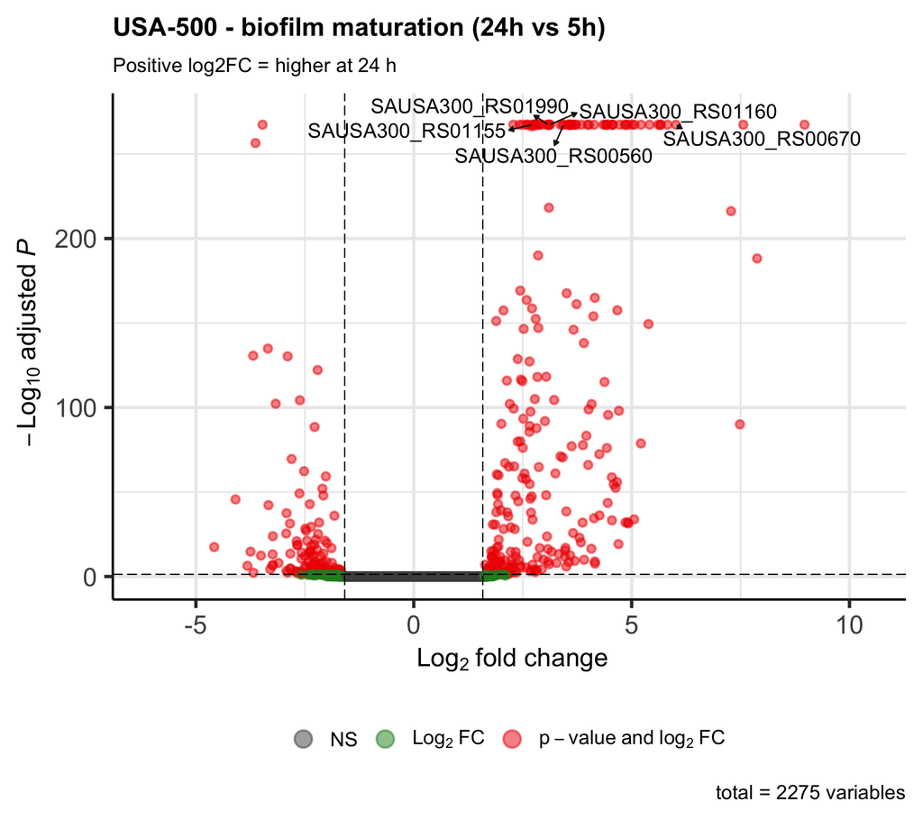

```r
plot_volcano(res_bf,
             paste0(strain, " - biofilm maturation (", last_tp, " vs ", first_tp, ")"),
             "Positive log2FC = higher at 24 h")
```

*Interpretation:* a substantial set of genes changes as the biofilm matures from 5 h to 24 h, split between genes induced and repressed with age. This is the biofilm’s own developmental programme, measured without any reference to the planktonic state.

### 1b Maturation within Planktonic

**❓ The question we are answering**

- **Question:** Within planktonic cultures, which genes change between 5 h and 24 h of growth?
- **Contrast:** Planktonic 24 h vs Planktonic 5 h. Reference = 5 h.
- **A positive log2FC means:** higher at 24 h.
- **A hit tells you:** this gene responds to culture ageing in planktonic cells (largely the entry into stationary phase).

```r
dds_pk <- dds_all[, dds_all$lifestyle == "Planktonic" &
                    dds_all$timepoint %in% c(first_tp, last_tp)]
dds_pk$timepoint <- relevel(droplevels(dds_pk$timepoint), ref = first_tp)
design(dds_pk)   <- ~ timepoint

dds_pk <- DESeq(dds_pk)
coef_pk <- paste0("timepoint_", last_tp, "_vs_", first_tp)
res_pk  <- get_results(dds_pk, coef_pk)

cat("Samples (planktonic):\n"); print(table(dds_pk$timepoint))
```

```
## Samples (planktonic):
```

```
##
##  5h 24h
##   4   8
```

```r
cat("\nCoefficient:", coef_pk, "\n")
```

```
##
## Coefficient: timepoint_24h_vs_5h
```

```r
cat(sprintf("DEG counts (padj < %s vs the %g-fold threshold):\n", padj_threshold, 2^lfc_threshold))
```

```
## DEG counts (padj < 0.05 vs the 3-fold threshold):
```

```r
print(table(res_pk$direction))
```

```
##
##              Up            Down Not significant
##              53             185            2037
```

```r
cat("\nMost extreme fold changes (check baseMean - high = real, single digits = low-count noise):\n")
```

```
##
## Most extreme fold changes (check baseMean - high = real, single digits = low-count noise):
```

```r
print(check_extreme_fc(res_pk))
```

```
##             gene_id baseMean log2FoldChange
## 1  SAUSA300_RS14295   4102.5          -8.34
## 2  SAUSA300_RS14290   2552.5          -7.90
## 3  SAUSA300_RS14285   3972.8          -7.63
## 4  SAUSA300_RS14280   5948.0          -7.09
## 5  SAUSA300_RS14275   1137.5          -6.41
## 6  SAUSA300_RS14330   2872.2          -5.95
## 7  SAUSA300_RS11860    106.6          -5.88
## 8  SAUSA300_RS14335   1960.8          -5.81
## 9  SAUSA300_RS11855     85.4          -5.52
## 10 SAUSA300_RS02400   1847.3          -5.51
##                                                                                                    padj
## 1  0.00000000000000000000000000000000000000000000000000000000000000000000000000000000000000000000000000
## 2  0.00000000000000000000000000000000000000000000000000000000000000000000000000000000000000000000000000
## 3  0.00000000000000000000000000000000000000000000000000000000000000000000000000000000000000000000000000
```

[output cut: 18 more lines]

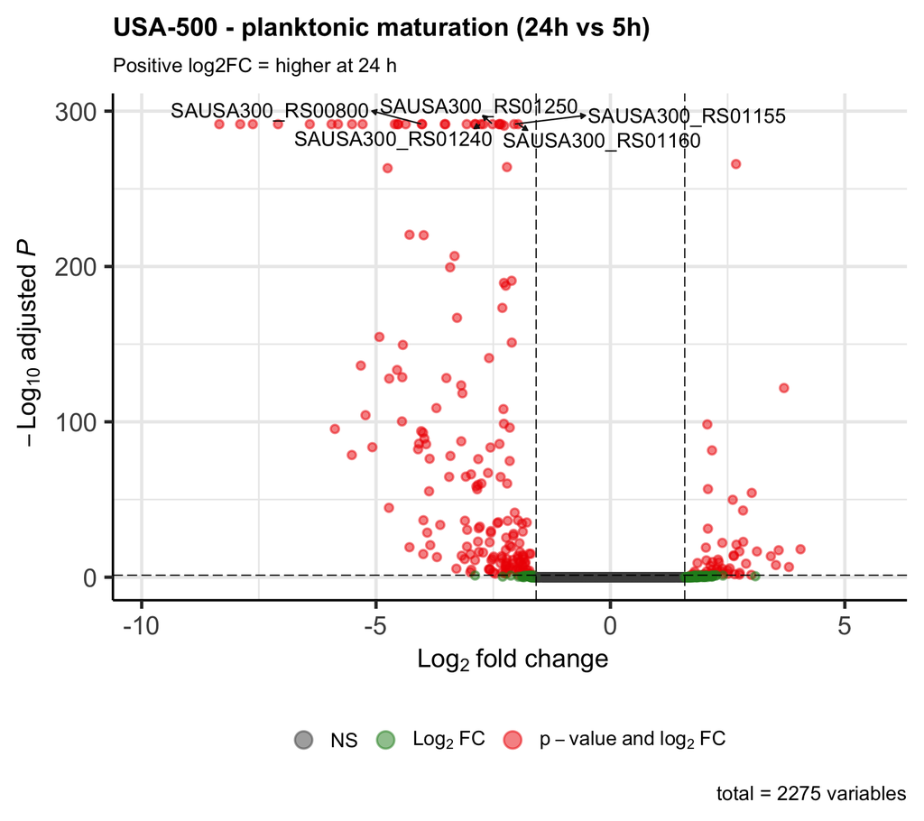

```r
plot_volcano(res_pk,
             paste0(strain, " - planktonic maturation (", last_tp, " vs ", first_tp, ")"),
             "Positive log2FC = higher at 24 h")
```

**💡 Tip - visualising operons in R.** Genes along a chromosome can be drawn as arrows with the `gggenes` package (a ggplot extension), coloured by fold change to show a coordinated operon response at a glance. This needs each gene’s genomic start/end/strand, which come from the reference annotation (GTF/GFF) rather than the count matrix. If those coordinates are available in the analysis object, the section below draws the neighbourhood of the top hit automatically.

### Visualising the Operon: Genes as Arrows Along the Chromosome

To see the coordinated shutdown directly, we read the gene coordinates from the reference GTF, take a window of genes centred on the strongest planktonic maturation hit, and draw them as arrows coloured by their fold change. A block of adjacent arrows all the same colour is the visual signature of an operon responding as a unit.

```r
# A GTF is a tab-delimited text file, so we read it directly with readr - no
# specialised genomics package is needed. We keep only the "gene" feature rows,
# then pull the fields we want out of the free-text attributes column with regex.
gtf_raw <- readr::read_tsv(
  gtf_path,
  comment   = "#",
  col_names = c("seqname", "source", "feature", "start", "end",
                "score", "strand", "frame", "attribute"),
  col_types = "ccciicccc",
  progress  = FALSE
) %>%
  filter(feature == "gene")

# Helper: pull the value of a named attribute (e.g. gene_id "SA_RS00145";)
extract_attr <- function(x, key) {
  m <- stringr::str_match(x, paste0(key, ' "([^"]*)"'))
  m[, 2]
}

coords <- gtf_raw %>%
  mutate(
    gene_id   = extract_attr(attribute, "gene_id"),
    gene_name = extract_attr(attribute, "gene"),          # real symbol if present
    locus_tag = extract_attr(attribute, "locus_tag")
  ) %>%
  mutate(gene_name = ifelse(is.na(gene_name) | gene_name == "", gene_id, gene_name)) %>%
  select(gene_id, gene_name, locus_tag, seqname, start, end, strand) %>%
  filter(!is.na(gene_id)) %>%
  distinct(gene_id, .keep_all = TRUE)

cat("Genes with coordinates parsed from GTF:", nrow(coords), "\n")
```

```
## Genes with coordinates parsed from GTF: 2928
```

```r
cat("Genes in results also found in GTF     :",
    sum(res_pk$gene_id %in% coords$gene_id), "of", nrow(res_pk), "\n")
```

```
## Genes in results also found in GTF     : 2275 of 2275
```

```r
print(head(coords, 3))
```

```
## # A tibble: 3 x 7
##   gene_id          gene_name locus_tag        seqname     start   end strand
##   <chr>            <chr>     <chr>            <chr>       <int> <int> <chr>
## 1 SAUSA300_RS00010 dnaA      SAUSA300_RS00010 NC_007793.1   544  1905 +
## 2 SAUSA300_RS00015 dnaN      SAUSA300_RS00015 NC_007793.1  2183  3316 +
## 3 SAUSA300_RS00020 yaaA      SAUSA300_RS00020 NC_007793.1  3697  3942 +
```

**📘 Note:** We match the DE results to the GTF by `gene_id` (the locus tag). This GTF also carries a `gene` attribute with the real gene symbol (e.g. *dnaA*), which we use for nicer labels when available and fall back to the locus tag otherwise. If the number matched were much lower than the number of genes, the identifier styles would differ between the count matrix and the GTF - here they are the same locus tags, so the match should be nearly complete.

```r
# --- Settings you can change --------------------------------------------------
window_genes <- 8   # how many genes to show on each side of the central hit
# -----------------------------------------------------------------------------

# 1. Pick the central gene: the strongest planktonic maturation hit that has coordinates
central_gene <- res_pk %>%
  filter(direction != "Not significant", gene_id %in% coords$gene_id) %>%
  arrange(padj, desc(abs(log2FoldChange))) %>%
  slice_head(n = 1) %>%
  pull(gene_id)

# 2. Order genes by genomic position on that contig and take a window around it
central_row <- coords %>% filter(gene_id == central_gene)

region <- coords %>%
  filter(seqname == central_row$seqname) %>%
  arrange(start) %>%
  mutate(idx = row_number())

central_idx <- region$idx[region$gene_id == central_gene]
lo <- max(1, central_idx - window_genes)
hi <- min(nrow(region), central_idx + window_genes)

region_window <- region %>%
  filter(idx >= lo, idx <= hi) %>%
  left_join(res_pk %>% select(gene_id, log2FoldChange, padj), by = "gene_id") %>%
  mutate(is_center = gene_id == central_gene)

cat("Central gene:", central_gene,
    "| contig:", central_row$seqname,
    "| window:", nrow(region_window), "genes\n")
```

```
## Central gene: SAUSA300_RS14295 | contig: NC_007793.1 | window: 17 genes
```

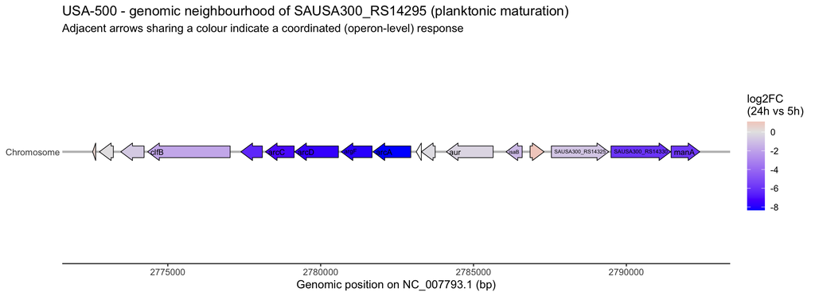

```r
# 3. Draw. We give gggenes the true start/end plus a 'forward' flag for strand,
#    and let it draw the arrowhead direction. Assign then print() so the plot
#    always renders inside the chunk.
operon_plot <- ggplot(
  region_window,
  aes(xmin = start, xmax = end, y = "Chromosome",
      fill = log2FoldChange, forward = (strand == "+"))
) +
  geom_gene_arrow(arrowhead_height = grid::unit(6, "mm"),
                  arrow_body_height = grid::unit(4, "mm")) +
  geom_gene_label(aes(label = gene_name), align = "left", min.size = 3) +
  scale_fill_gradient2(low = "blue", mid = "grey90", high = "red",
                       midpoint = 0, name = "log2FC\n(24h vs 5h)",
                       na.value = "white") +
  theme_genes() +
  theme(axis.title.y = element_blank(), legend.position = "right") +
  labs(
    x     = paste0("Genomic position on ", central_row$seqname, " (bp)"),
    title = paste0(strain, " - genomic neighbourhood of ", central_gene,
                   " (planktonic maturation)"),
    subtitle = "Adjacent arrows sharing a colour indicate a coordinated (operon-level) response"
  )

print(operon_plot)
```

```r
ggsave(file.path(results_dir, "plots", paste0("operon_", strain_tag, ".png")),
       operon_plot, width = 11, height = 4, dpi = 300)
```

**💡 Tip:** Increase or decrease `window_genes` to widen or narrow the region shown. Genes coloured white have no fold-change value (they were filtered out in QC for low counts, or are not in the results). A run of same-coloured arrows flanked by grey/white neighbours is a strong hint that you are looking at a single transcriptional unit.

**📘 Interpreting the plot - is this really an operon?** Three features together justify calling a block of genes an operon, and you can read all three straight off this figure:

- **Co-location** - the strongly-coloured genes are immediate neighbours on the chromosome, with no unrelated genes breaking up the block.
- **Co-orientation** - the arrows all point the same way (same strand), which is required for genes to be transcribed together into one mRNA.
- **Co-regulation** - they all change by a similar, large amount in the same direction (here a coordinated shutdown of roughly 7–8 log2 units in planktonic cells by 24 h).

**Challenge:** read the gene symbols on the coloured arrows and look a few of them up (NCBI Gene, or the reference annotation). You should find they belong to a single, named metabolic pathway. Which pathway is it, what does it let the cell do, and why would that pathway be switched off as a planktonic culture ages into stationary phase? Relate your answer to the “dormancy / metabolic slow-down” biology the paper describes.

**A note on rigour:** co-location + co-orientation + co-regulation make a very strong *inference* that these genes form an operon, but strictly, “operon” means transcription from a single promoter into one mRNA - proving that needs operon-mapping evidence (e.g. transcript read-through across gene boundaries) or prior literature. For well-studied organisms like *S. aureus*, the identity of the block can be confirmed directly against the published literature.

### Comparing the Two Maturation Programmes

The two lists answer “what changes with time” in each lifestyle. Overlapping genes change with age regardless of lifestyle (general ageing / stationary-phase response); genes unique to one list are the lifestyle-specific part of maturation.

```r
sig_bf <- res_bf %>% filter(direction != "Not significant") %>% pull(gene_id)
sig_pk <- res_pk %>% filter(direction != "Not significant") %>% pull(gene_id)

overlap_tbl <- tibble(
  set   = c("Biofilm only", "Planktonic only", "Shared", "Biofilm total", "Planktonic total"),
  n     = c(length(setdiff(sig_bf, sig_pk)),
            length(setdiff(sig_pk, sig_bf)),
            length(intersect(sig_bf, sig_pk)),
            length(sig_bf),
            length(sig_pk))
)
kable(overlap_tbl, caption = "Maturation DEGs: overlap between lifestyles") %>%
  kable_styling(bootstrap_options = c("striped", "hover"), full_width = FALSE)
```

Maturation DEGs: overlap between lifestyles

| set | n |
| --- | --- |
| Biofilm only | 323 |
| Planktonic only | 147 |
| Shared | 91 |
| Biofilm total | 414 |
| Planktonic total | 238 |

## Part 2 Lifestyle: Biofilm vs Planktonic, Accounting for Time

Now we ask how biofilm differs from planktonic. Because the two lifestyles are sampled at the same set of time points, we can model lifestyle **while adjusting for time**, instead of comparing at a single confounded snapshot. We show two models that ask subtly different questions.

We use all three time points so the time term is meaningful.

```r
dds_ls <- dds_all
dds_ls$lifestyle <- relevel(droplevels(dds_ls$lifestyle), ref = "Planktonic")
dds_ls$timepoint <- relevel(droplevels(dds_ls$timepoint), ref = "5h")

cat("Design table:\n")
```

```
## Design table:
```

```r
print(table(dds_ls$lifestyle, dds_ls$timepoint))
```

```
##
##              5h 10h 24h
##   Planktonic  4   4   8
##   Biofilm     4   4   8
```

### 2a Additive Model: the Lifestyle Effect, Adjusted for Time

**❓ The question we are answering**

- **Question:** Averaging across time, which genes differ between biofilm and planktonic once the shared time trend is removed?
- **Model:** `~ timepoint + lifestyle`. The `timepoint` term absorbs the ageing effect common to both lifestyles; the `lifestyle` term is then the biofilm-vs-planktonic difference on top of that.
- **A positive log2FC means:** higher in biofilm.
- **A hit tells you:** this gene differs by lifestyle in a way that is consistent across time - a candidate core biofilm-vs-planktonic gene, not just a growth-phase artefact.

```r
design(dds_ls) <- ~ timepoint + lifestyle
dds_add <- DESeq(dds_ls)
cat("resultsNames:\n"); print(resultsNames(dds_add))
```

```
## resultsNames:
```

```
## [1] "Intercept"                       "timepoint_10h_vs_5h"
## [3] "timepoint_24h_vs_5h"             "lifestyle_Biofilm_vs_Planktonic"
```

```r
res_add <- get_results(dds_add, "lifestyle_Biofilm_vs_Planktonic")
cat(sprintf("\nDEG counts (padj < %s vs the %g-fold threshold):\n", padj_threshold, 2^lfc_threshold))
```

```
##
## DEG counts (padj < 0.05 vs the 3-fold threshold):
```

```r
print(table(res_add$direction))
```

```
##
##              Up            Down Not significant
##              54              21            2200
```

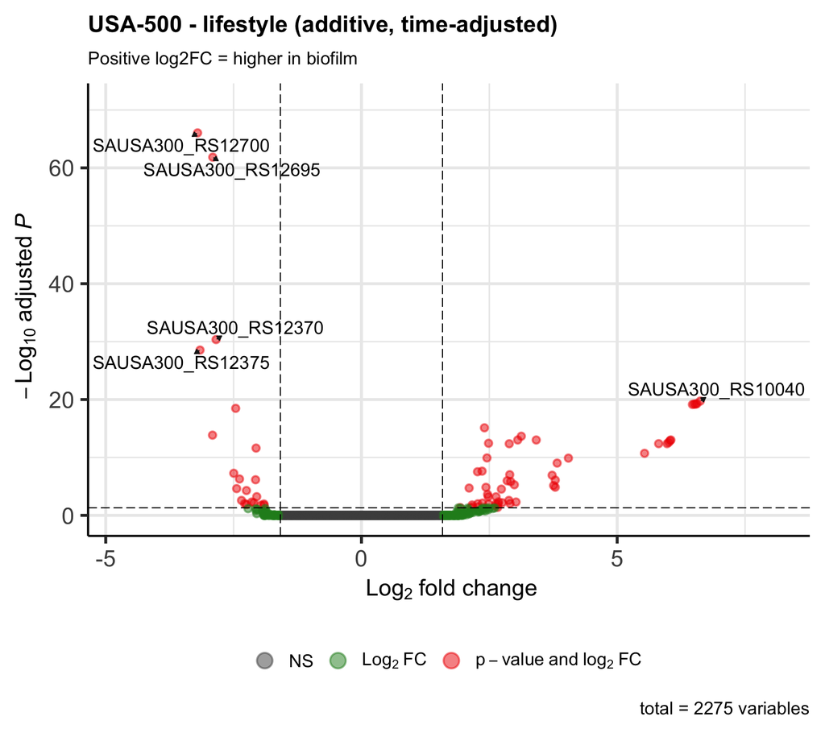

```r
plot_volcano(res_add,
             paste0(strain, " - lifestyle (additive, time-adjusted)"),
             "Positive log2FC = higher in biofilm")
```

*Interpretation:* once the shared ageing trend is removed by the `timepoint` term, the number of lifestyle genes is much smaller than a naive single-time-point comparison would give. That drop is the growth-phase confound being taken out: many genes that look “biofilm-specific” at 24 h are really just ageing effects common to both cultures. What remains is a cleaner candidate set of genes that differ by lifestyle regardless of time.

**⭐ What the additive model assumes.** It assumes the lifestyle difference is *the same size at every time point* (only the baseline shifts with time, not the lifestyle gap). This is a strong assumption. If the biofilm-vs-planktonic difference actually grows with age - which the paper suggests - then a single “average” lifestyle effect is an oversimplification. The interaction model below tests exactly that.

### 2b Interaction Model: Does the Lifestyle Difference Change with Time?

**❓ The question we are answering**

- **Question:** Is the biofilm-vs-planktonic difference the same at every time point, or does it change as the cultures age?
- **Model:** `~ timepoint + lifestyle + timepoint:lifestyle`. The interaction terms capture how much the lifestyle gap at 10 h or 24 h differs from the lifestyle gap at 5 h.
- **A hit tells you:** this gene’s biofilm-vs-planktonic difference is time-dependent - it is part of the “response strengthens (or weakens) with maturation” signal.

```r
# Set the full (interaction) design. We fit it with an LRT below, comparing it
# to the additive model, so we do not need a separate Wald fit here.
design(dds_ls) <- ~ timepoint + lifestyle + timepoint:lifestyle
```

**📘 Note - testing the interaction, not a single coefficient.** “Does the lifestyle gap change with time?” is a question about *all* the interaction terms together, so we test them jointly with a likelihood-ratio test (LRT): the full model above versus a reduced model without the interaction. A gene is significant if adding the interaction terms improves the fit - i.e. its lifestyle difference is not constant across time. Because significance here comes from comparing two models (not from one fold-change coefficient), we report the LRT p-value and use the model’s own fold-change columns for description rather than apeglm shrinkage.

```r
dds_lrt <- DESeq(dds_ls, test = "LRT", reduced = ~ timepoint + lifestyle)
cat("resultsNames (full interaction model):\n"); print(resultsNames(dds_lrt))
```

```
## resultsNames (full interaction model):
```

```
## [1] "Intercept"                       "timepoint_10h_vs_5h"
## [3] "timepoint_24h_vs_5h"             "lifestyle_Biofilm_vs_Planktonic"
## [5] "timepoint10h.lifestyleBiofilm"   "timepoint24h.lifestyleBiofilm"
```

```r
# Careful: in an LRT result the log2FoldChange column is NOT "the" lifestyle
# effect - it is only the last interaction coefficient (timepoint24h.lifestyleBiofilm).
# Use the padj for the test; describe effect sizes with the profile plots below.
res_lrt <- as.data.frame(results(dds_lrt)) %>%
  rownames_to_column("gene_id") %>%
  arrange(padj)

n_sig_lrt <- sum(res_lrt$padj < padj_threshold, na.rm = TRUE)
cat("\nGenes with a time-dependent lifestyle difference (LRT padj <", padj_threshold, "):",
    n_sig_lrt, "\n")
```

```
##
## Genes with a time-dependent lifestyle difference (LRT padj < 0.05 ): 2117
```

**How to read the plot below:** each panel is one gene; the two lines show its expression over time in the two lifestyles. Parallel lines = no interaction; diverging, converging or crossing lines = the lifestyle difference changes with time.

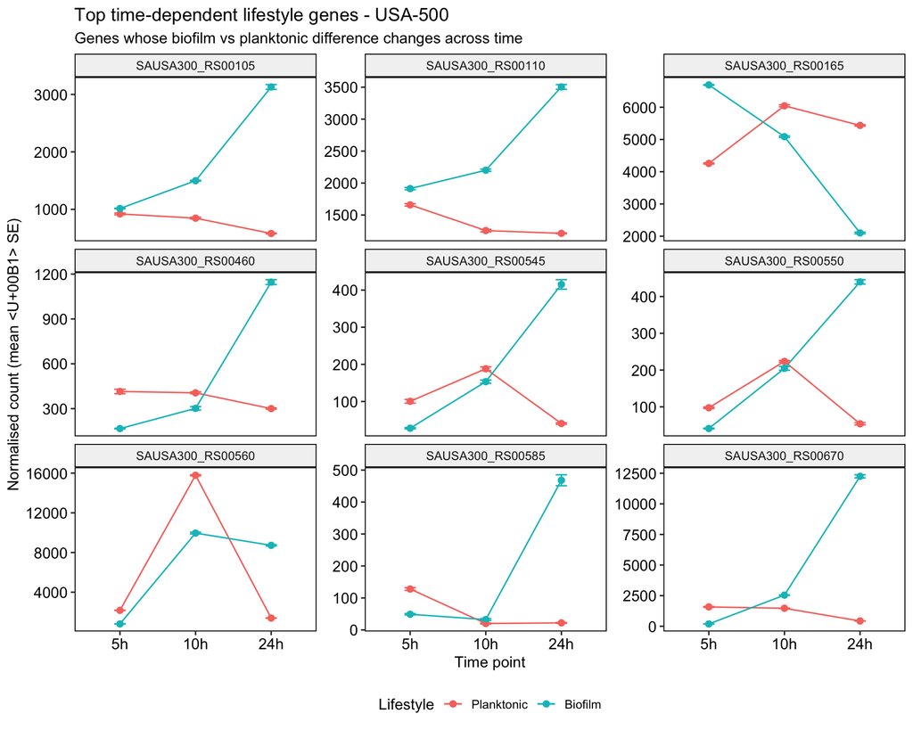

```r
top_int <- res_lrt %>% filter(!is.na(padj)) %>% slice_head(n = 9) %>% pull(gene_id)

if (length(top_int) >= 1) {
  norm_ls <- counts(dds_lrt, normalized = TRUE)

  profile_df <- norm_ls[top_int, , drop = FALSE] %>%
    as.data.frame() %>%
    rownames_to_column("gene_id") %>%
    pivot_longer(-gene_id, names_to = "sample", values_to = "norm_count") %>%
    left_join(
      as.data.frame(colData(dds_lrt)) %>%
        mutate(sample = rownames(.)) %>%
        select(sample, lifestyle, timepoint),
      by = "sample"
    ) %>%
    mutate(timepoint = factor(timepoint, levels = c("5h", "10h", "24h")))

  profile_summary <- profile_df %>%
    group_by(gene_id, lifestyle, timepoint) %>%
    summarise(mean_count = mean(norm_count),
              se         = sd(norm_count) / sqrt(n()),
              .groups    = "drop")

  ggplot(profile_summary,
         aes(x = timepoint, y = mean_count, colour = lifestyle, group = lifestyle)) +
    geom_point(size = 2) +
    geom_line() +
    geom_errorbar(aes(ymin = mean_count - se, ymax = mean_count + se), width = 0.15) +
    facet_wrap(~ gene_id, scales = "free_y") +
    theme_pubr(border = TRUE) +
    theme(legend.position = "bottom") +
    labs(x = "Time point", y = "Normalised count (mean ± SE)", colour = "Lifestyle",
         title = paste0("Top time-dependent lifestyle genes - ", strain),
         subtitle = "Genes whose biofilm vs planktonic difference changes across time")
} else {
  cat("No time-dependent genes to plot.\n")
}
```

**📘 Note - a subtlety about the two models.** The additive model’s single lifestyle effect and the interaction test’s near-universal significance are not in conflict: the additive effect is the lifestyle difference *averaged* over time, while the interaction asks whether that difference is *constant*. Both can be true at once - there is an average difference, and it also changes with time. Which one you report depends on the question you are asking.

### Additive vs Interaction: Which Should You Use?

- The **additive model** (`~ timepoint + lifestyle`) gives one clean lifestyle effect, averaged over time. Use it when the lifestyle difference is roughly constant across time, and when you want a single, interpretable biofilm-vs-planktonic gene list.
- The **interaction model** (`+ timepoint:lifestyle`) asks whether that difference *changes* with age. Use it when the timing of the response is the biology of interest - as it is in this paper, where biofilm divergence is reported to grow in mature biofilms.

They are not competitors so much as answers to different questions. A common workflow is to look at the interaction first: if few genes have a significant interaction, the additive model is a fair summary; if many do, the “average” lifestyle effect hides important time-dependence and should be interpreted with care.

**📘 Note - for you to write in class.** Compare the number of significant genes from the additive model (2a) with the number of time-dependent genes from the interaction (2b). What does the ratio tell you about whether a single “biofilm vs planktonic” number is meaningful for this strain? Does the answer differ between USA100 and USA500?

## Part 3 A Closer Look: Does the Strongest Biofilm Producer Show the Strongest Biofilm-vs-Planktonic Difference?

**❓ The question we are answering**

- **Question:** In the paper’s crystal-violet assay, USA500 forms the most biofilm biomass. Does it also show the largest *transcriptional* difference between biofilm and planktonic cells?
- **Contrast:** Biofilm vs Planktonic at 24 h only (the mature biofilm state). Reference = Planktonic.
- **Why 24 h:** this is the single time point that best represents a mature biofilm, so it is the most direct molecular counterpart to the biomass phenotype.

**⭐ A deliberate, clearly-labelled trade-off.** This single-time-point contrast is **confounded with growth phase** - at 24 h, planktonic cells are deep in stationary phase, so some of the difference reflects growth state rather than lifestyle. We know this (it is exactly why the main lifestyle analysis in Part 2 adjusts for time). We compute it here *anyway*, and only for this specific hypothesis, because “biofilm biomass” is a mature-culture phenotype and the 24 h snapshot is its closest transcriptional match. Treat the number as “how different are mature biofilm and planktonic cells overall”, not as a clean lifestyle-only signal.

**⭐ This compares two analyses; it does not test the difference between them.** The question “does USA500 respond more strongly?” is really a *strain x lifestyle interaction*. We cannot fit that model: the two strains were mapped to different references, so they have different gene identifiers and no shared coordinate system to put them in one design.  
What we do instead is run each strain separately and compare how many genes reached significance. That is not the same thing. A larger count in one strain does not establish that its lifestyle effect is *significantly* larger - the counts also depend on library size, dispersion and how well the reads matched that strain’s reference. Read the comparison as a description worth discussing, not as a result.

**📘 A key caution about comparing counts across strains.** USA500 has no finished genome of its own, so its reads were aligned to the **USA300** reference (its closest sequenced relative), while USA100 was aligned to its own N315 reference. Differences in DEG counts between the two strains therefore mix *real biology* with *reference-mapping effects* (reads from USA500-specific or divergent genes may map imperfectly to USA300). Keep this in mind: a difference in counts is a starting point for discussion, not a clean quantitative comparison.

```r
# Biofilm vs planktonic at 24h only - the mature-biofilm snapshot
dds_24 <- dds_all[, dds_all$timepoint == "24h"]
dds_24$timepoint <- droplevels(dds_24$timepoint)
dds_24$lifestyle <- relevel(droplevels(dds_24$lifestyle), ref = "Planktonic")
design(dds_24)   <- ~ lifestyle

dds_24 <- DESeq(dds_24)
res_24 <- get_results(dds_24, "lifestyle_Biofilm_vs_Planktonic")

n_deg_24 <- sum(res_24$direction != "Not significant")
cat("Samples at 24h:\n"); print(table(dds_24$lifestyle))
```

```
## Samples at 24h:
```

```
##
## Planktonic    Biofilm
##          8          8
```

```r
cat(sprintf("\nBiofilm vs planktonic DEGs at 24h (padj < %s vs the %g-fold threshold): %d\n",
            padj_threshold, 2^lfc_threshold, n_deg_24))
```

```
##
## Biofilm vs planktonic DEGs at 24h (padj < 0.05 vs the 3-fold threshold): 422
```

```r
print(table(res_24$direction))
```

```
##
##              Up            Down Not significant
##             317             105            1853
```

```r
# Save this strain's result to a shared file so both strains can be compared
# after each has been rendered once.
summary_dir  <- file.path(git_root, "results", "cross_strain")
dir.create(summary_dir, recursive = TRUE, showWarnings = FALSE)
summary_file <- file.path(summary_dir, "biofilm_vs_planktonic_24h.tsv")

row <- tibble(strain = strain, n_DEG_24h = n_deg_24,
              n_up = sum(res_24$direction == "Up"),
              n_down = sum(res_24$direction == "Down"))

if (file.exists(summary_file)) {
  prev <- readr::read_tsv(summary_file, show_col_types = FALSE) %>%
    filter(strain != !!strain)          # replace this strain's old row if re-run
  row <- bind_rows(prev, row)
}
readr::write_tsv(row, summary_file)
```

### Cross-Strain Comparison of the Hypothesis

This table fills in as you render each strain. Run the script once with `strain <- "USA-100"` and once with `strain <- "USA-500"`; both rows will then appear.

```r
cross <- readr::read_tsv(summary_file, show_col_types = FALSE) %>% arrange(strain)
kable(cross, caption = "Biofilm vs planktonic at 24h - DEG counts by strain") %>%
  kable_styling(bootstrap_options = c("striped", "hover"), full_width = FALSE)
```

Biofilm vs planktonic at 24h - DEG counts by strain

| strain | n_DEG_24h | n_up | n_down |
| --- | --- | --- | --- |
| USA-100 | 490 | 263 | 227 |
| USA-500 | 422 | 317 | 105 |

**📘 Interpreting the hypothesis test.** The prediction was that USA500, the strongest biofilm *producer* in the biomass assay, would also show the largest biofilm-vs-planktonic *transcriptional* difference. When both strains are present in the table above, check whether that holds. If it does not, that is a genuinely interesting result: **how much biofilm a strain builds (a phenotype) and how differently its biofilm and planktonic cells express genes (a molecular signal) are two different things, and they need not agree.** A strain can form abundant biofilm biomass while its biofilm and planktonic transcriptomes remain relatively similar, or vice versa. Remember also the reference-mapping caveat above before drawing firm quantitative conclusions.

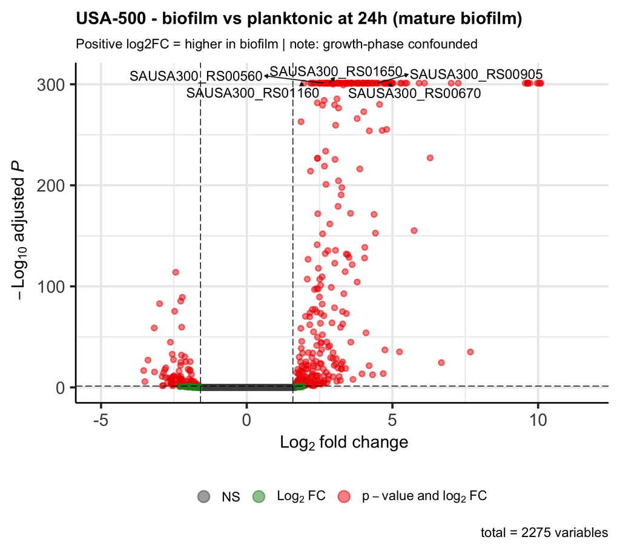

```r
plot_volcano(res_24,
             paste0(strain, " - biofilm vs planktonic at 24h (mature biofilm)"),
             "Positive log2FC = higher in biofilm | note: growth-phase confounded")
```

## Save Results

```r
write_tsv(res_bf,  file.path(results_dir, "tables",
          paste0("DE_", strain_tag, "_maturation_biofilm_", last_tp, "_vs_", first_tp, ".tsv")))
write_tsv(res_pk,  file.path(results_dir, "tables",
          paste0("DE_", strain_tag, "_maturation_planktonic_", last_tp, "_vs_", first_tp, ".tsv")))
write_tsv(res_add, file.path(results_dir, "tables",
          paste0("DE_", strain_tag, "_lifestyle_additive.tsv")))
write_tsv(res_lrt, file.path(results_dir, "tables",
          paste0("DE_", strain_tag, "_lifestyle_interaction_LRT.tsv")))
write_tsv(res_24, file.path(results_dir, "tables",
          paste0("DE_", strain_tag, "_biofilm_vs_planktonic_24h.tsv")))

cat("✅ Saved all result tables for", strain, "\n")
```

```
## ✅ Saved all result tables for USA-500
```

## Summary

| Part | Question | Design | Reference |
| --- | --- | --- | --- |
| 1a | What changes as biofilm matures? | `~ timepoint` (biofilm only) | 5 h |
| 1b | What changes as planktonic ages? | `~ timepoint` (planktonic only) | 5 h |
| 2a | Lifestyle effect, averaged over time | `~ timepoint + lifestyle` | Planktonic |
| 2b | Does the lifestyle effect change with time? | LRT: interaction vs additive | - |
| 3 | Does the strongest biofilm producer show the strongest biofilm-vs-planktonic difference? | `~ lifestyle` (24 h only) | Planktonic |

**⭐ Important:** All results are for a **single strain**. The two strains use different reference genomes (N315 for USA100, USA300 for USA500), so their locus tags are not comparable and the gene lists are never merged. Run this script once per strain by changing the `strain` setting at the top.

## Interpretation questions

1. The script sets planktonic as the reference, so a positive fold change means “up in biofilm”. If you swapped the reference, what would change in the numbers - and what would change only in how you tell the story? For *S. aureus* living on a catheter in a patient, which lifestyle is really the “normal” one?
2. Pick one gene from your nine-panel profile plot. Looking at its two lines: is the interaction driven by the biofilm cells changing, the planktonic cells changing, or a real crossover? Now imagine sampling had stopped at 10 h - what would you have concluded about this gene? What decides the answer: the biology, or the time window you measured?
3. The hypothesis: USA500, the strongest biofilm producer in the paper’s assay, should show the biggest biofilm-vs-planktonic difference at 24 h. Compare your cross-strain table with a group that analysed the other strain. Did the hypothesis hold? Suggest two possible explanations for what you see - one biological, one technical. (Hint: which reference genome were the USA500 reads mapped to?)